# Pertemuan 3 - Regresi dengan Peubah Lag

Abie Septian G1401231069

## *Packages*

```r
library(dLagM)
library(dynlm)
library(MLmetrics)
library(lmtest)
library(car)
```

## Impor Data

```r
aqnewdelhi <- read.csv("C:/Users/Abie/OneDrive/Documents/5/mpdw/NewDelhi_Air_quality.csv")
str(aqnewdelhi)
```

```
## 'data.frame':    72 obs. of  12 variables:
##  $ X              : int  0 1 2 3 4 5 6 7 8 9 ...
##  $ AQI            : num  30.2 28.2 26.6 25 26 26 26 24 23 24 ...
##  $ CO             : num  199 198 199 202 205 ...
##  $ datetime       : chr  "2022-10-21:18" "2022-10-21:19" "2022-10-21:20" "2022-10-21:21" ...
##  $ no2            : num  0.0469 0.0465 0.0469 0.0482 0.0489 ...
##  $ o3             : num  55.8 54.9 54.6 55.1 55.8 ...
##  $ pm10           : num  10.5 10.7 11.2 11.1 10.4 ...
##  $ pm25           : num  5.64 4.62 3.52 2.23 1.98 ...
##  $ so2            : num  0.387 0.41 0.402 0.376 0.339 ...
##  $ timestamp_local: chr  "2022-10-21T23:00:00" "2022-10-22T00:00:00" "2022-10-22T01:00:00" "2022-10-22T02:00:00" ...
##  $ timestamp_utc  : chr  "2022-10-21T18:00:00" "2022-10-21T19:00:00" "2022-10-21T20:00:00" "2022-10-21T21:00:00" ...
##  $ ts             : int  1666375200 1666378800 1666382400 1666386000 1666389600 1666393200 1666396800 1666400400 1666404000 1666407600 ...
```

## Subset Data

```r
aqnewdelhi<-aqnewdelhi[,c(1,2,5)]
colnames(aqnewdelhi)<-c("t","Yt","Xt")
aqnewdelhi
```

```
##     t   Yt         Xt
## 1   0 30.2 0.04685717
## 2   1 28.2 0.04645554
## 3   2 26.6 0.04685717
## 4   3 25.0 0.04819594
## 5   4 26.0 0.04886533
## 6   5 26.0 0.05020411
## 7   6 26.0 0.05020411
## 8   7 24.0 0.05020411
## 9   8 23.0 0.04685717
## 10  9 24.0 0.04417961
## 11 10 25.0 0.04284084
## 12 11 26.0 0.04049798
## 13 12 27.0 0.04016329
## 14 13 29.0 0.03882451
```

[output cut: 58 more lines]

## Pembagian Data

```r
#SPLIT DATA
train<-aqnewdelhi[1:58,]
test<-aqnewdelhi[59:72,]
```

```r
#data time series
train.ts<-ts(train)
test.ts<-ts(test)
aqnewdelhi.ts<-ts(aqnewdelhi)
```

## Model Koyck

$$y_t=a(1-\lambda)+\beta_0X_t+\beta_1Z_t+\lambda Y_{t-1}+V_t$$

dengan
$$V_t=u_t-\lambda
u_{t-1}$$

### Pemodelan

```r
# Model Koyck
model.koyck <- koyckDlm(x = train$Xt, y = train$Yt)
summary(model.koyck)
```

```
##
## Call:
## "Y ~ (Intercept) + Y.1 + X.t"
##
## Residuals:
##      Min       1Q   Median       3Q      Max
## -2.14846 -0.54834 -0.04671  0.55341  2.25964
##
## Coefficients:
##             Estimate Std. Error t value Pr(>|t|)
## (Intercept)  1.99147    1.58621   1.255    0.215
## Y.1          0.88020    0.06305  13.960   <2e-16 ***
## X.t         25.33442   18.07104   1.402    0.167
## ---
## Signif. codes:  0 '***' 0.001 '**' 0.01 '*' 0.05 '.' 0.1 ' ' 1
##
## Residual standard error: 0.936 on 54 degrees of freedom
## Multiple R-Squared: 0.8243,  Adjusted R-squared: 0.8178
## Wald test: 125.9 on 2 and 54 DF,  p-value: < 2.2e-16
##
## Diagnostic tests:
## NULL
##
##                             alpha     beta       phi
## Geometric coefficients:  16.62273 25.33442 0.8801961
```

```r
# Ukuran Kebaikan Model
AIC(model.koyck)
```

```
## [1] 159.136
```

```r
BIC(model.koyck)
```

```
## [1] 167.3082
```

$$\hat{Y_t}=1.99147+25.33442X_t+0.8802Y_{t-1}$$
Model tersebut memiliki nilai: - Adj R²= 0.8178

- AIC= 159.136
- BIC= 167.3082

### Peramalan dan Akurasi

```r
forec.koyck <- forecast(model = model.koyck, x=test$Xt, h=14)
forec.koyck
```

```
## $forecasts
##  [1] 22.93128 22.71392 22.42934 22.13221 21.86644 21.69610 21.64792 21.69879
##  [9] 21.86227 22.13336 22.46524 22.88455 23.32146 23.72298
##
## $call
## forecast.koyckDlm(model = model.koyck, x = test$Xt, h = 14)
##
## attr(,"class")
## [1] "forecast.koyckDlm" "dLagM"
```

```r
# Ukuran Kebaikan Model
#akurasi data test
mape.koyck <- MAPE(forec.koyck$forecasts, test$Yt)
mape.koyck
```

```
## [1] 0.08785389
```

```r
#akurasi data training
GoF(model.koyck)
```

```
##              n       MAE          MPE       MAPE    sMAPE     MASE       MSE
## model.koyck 57 0.7025115 -0.001149676 0.02619192 0.026114 1.057544 0.8299675
##                  MRAE    GMRAE
## model.koyck 975249991 11827.09
```

## Model Distributed Lag

### Pemodelan (Lag=2)

```r
model.dlm <- dlm(x = train$Xt,y = train$Yt , q = 2)
summary(model.dlm)
```

```
##
## Call:
## lm(formula = model.formula, data = design)
##
## Residuals:
##     Min      1Q  Median      3Q     Max
## -4.1732 -1.3324 -0.2241  0.8610  3.9745
##
## Coefficients:
##             Estimate Std. Error t value Pr(>|t|)
## (Intercept)   20.172      1.652  12.207   <2e-16 ***
## x.t          203.517    111.604   1.824   0.0740 .
## x.1         -291.196    198.583  -1.466   0.1486
## x.2          240.707    117.925   2.041   0.0463 *
## ---
## Signif. codes:  0 '***' 0.001 '**' 0.01 '*' 0.05 '.' 0.1 ' ' 1
##
## Residual standard error: 1.957 on 52 degrees of freedom
## Multiple R-squared:  0.2564, Adjusted R-squared:  0.2135
## F-statistic: 5.976 on 3 and 52 DF,  p-value: 0.001405
##
## AIC and BIC values for the model:
##        AIC     BIC
## 1 239.9943 250.121
```

```r
# Ukuran Kebaikan Model
AIC(model.dlm)
```

```
## [1] 239.9943
```

```r
BIC(model.dlm)
```

```
## [1] 250.121
```

Dari hasil diatas, didapat bahwa $P-value$ dari intercept dan $x_{t-2}$ (kadar NO2) $<0.05$. Hal ini menunjukkan bahwa intercept dan kadar NO2 di 2 periode sebelumnya berpengaruh signifikan terhadap Indeks Kualitas Udara di New Delhi. Adapun model keseluruhan yang terbentuk adalah sebagai berikut

$$\hat{Y_t}=20.172+203.517X_t-291.196X_{t-1}+240.707X_{t-2}$$
Model tersebut memiliki nilai: - Adj R²= 0.21

- AIC= 239.9943
- BIC= 250.121

### Peramalan dan Akurasi

```r
forec.dlm <- forecast(model = model.dlm, x=test$Xt, h=14)
forec.dlm
```

```
## $forecasts
##  [1] 25.89563 25.44779 24.16522 23.37225 22.98803 23.10453 23.15068 23.33464
##  [9] 24.18294 24.72641 25.14165 26.29976 26.26895 26.83394
##
## $call
## forecast.dlm(model = model.dlm, x = test$Xt, h = 14)
##
## attr(,"class")
## [1] "forecast.dlm" "dLagM"
```

```r
#akurasi data test
mape.dlm <- MAPE(forec.dlm$forecasts, test$Yt)
mape.dlm
```

```
## [1] 0.1292341
```

```r
#akurasi data training
GoF(model.dlm)
```

```
##            n      MAE          MPE       MAPE      sMAPE     MASE      MSE
## model.dlm 56 1.455773 -0.004752166 0.05344367 0.05324703 2.249088 3.557875
##                 MRAE    GMRAE
## model.dlm 6191482292 28850.15
```

### *Lag* Optimum

Jika tadi lag ditentukan, maka pada bagian ini akan dicari lag optimum

```r
#penentuan lag optimum
finiteDLMauto(formula = Yt ~ Xt,
              data = data.frame(train), q.min = 1, q.max = 8,
              model.type = "dlm", error.type = "AIC", trace = TRUE)
```

```
##   q - k    MASE      AIC      BIC    GMRAE    MBRAE R.Adj.Sq    Ljung-Box
## 8     8 2.08169 211.3028 232.3350 40397.08  4.04480  0.36542 1.654175e-07
## 7     7 2.18686 219.7987 239.1170 34340.25  1.76283  0.31099 1.947563e-08
## 6     6 2.16325 223.6641 241.2253 28976.64  2.26638  0.29359 3.377353e-09
## 5     5 2.18073 228.6285 244.3909 31773.29  2.77409  0.26048 1.905553e-09
## 4     4 2.21937 233.2316 247.1545 35199.94 12.84165  0.23155 5.861548e-10
## 3     3 2.28713 237.6810 249.7250 32757.45  1.08578  0.21352 2.364642e-10
## 2     2 2.24909 239.9943 250.1210 28850.15  1.01775  0.21346 1.492265e-10
## 1     1 2.34359 245.7191 253.8913 26698.16  0.45855  0.16755 4.335832e-11
```

Berdasarkan output tersebut, lag optimum dari rentang 1-8 didapatkan ketika lag=8. Selanjutnya dilakukan pemodelan untuk lag=8

```r
# Model dlm dengan lag optimum (=8)
model.dlm2 <- dlm(x = train$Xt,y = train$Yt , q = 8)
summary(model.dlm2)
```

```
##
## Call:
## lm(formula = model.formula, data = design)
##
## Residuals:
##     Min      1Q  Median      3Q     Max
## -4.5777 -0.9493  0.1011  0.9497  2.9560
##
## Coefficients:
##             Estimate Std. Error t value Pr(>|t|)
## (Intercept)   14.158      2.256   6.275 1.94e-07 ***
## x.t          253.711    110.759   2.291   0.0273 *
## x.1         -273.258    238.762  -1.144   0.2592
## x.2          218.193    293.894   0.742   0.4622
## x.3          -30.109    306.731  -0.098   0.9223
## x.4           37.238    312.799   0.119   0.9058
## x.5          -54.997    311.978  -0.176   0.8610
## x.6           70.591    303.349   0.233   0.8172
## x.7          -25.868    254.516  -0.102   0.9196
## x.8           96.723    121.229   0.798   0.4297
## ---
## Signif. codes:  0 '***' 0.001 '**' 0.01 '*' 0.05 '.' 0.1 ' ' 1
##
## Residual standard error: 1.796 on 40 degrees of freedom
## Multiple R-squared:  0.482,  Adjusted R-squared:  0.3654
## F-statistic: 4.135 on 9 and 40 DF,  p-value: 0.0008059
##
## AIC and BIC values for the model:
##        AIC     BIC
## 1 211.3028 232.335
```

```r
# Ukuran Kebaikan Model
AIC(model.dlm2)
```

```
## [1] 211.3028
```

```r
BIC(model.dlm2)
```

```
## [1] 232.335
```

Dari hasil diatas, didapat bahwa $P-value$ dari intercept dan $x_t$ (kadar NO2) $<0.05$. Hal ini menunjukkan bahwa intercept dan kadar NO2 di periode yang sama berpengaruh signifikan terhadap Indeks Kualitas Udara di New Delhi. Adapun model keseluruhan yang terbentuk adalah sebagai berikut

$$\hat{Y_t}=14.158+253.711X_t-273.258X_{t-1}+218.193X_{t-2}-30.109X_{t-3}+37.238X_{t-4}-54.997X_{t-5}+70.591X_{t-6}-25.868X_{t-7}+96.723X_{t-8}$$
Model tersebut memiliki nilai: - Adj R²= 0.3654

- AIC= 211.3028
- BIC= 232.335

ketiga indikator menunjukan hasil yang lebih baik dibandingkan model sebelumnya ketika lag ditentukan (lag=2)

Adapun hasil peramalan 14 periode kedepan menggunakan model tersebut adalah sebagai berikut

```r
#peramalan dan akurasi
forec.dlm2 <- forecast(model = model.dlm2, x=test$Xt, h=14)

#akurasi data test
mape.dlm2<- MAPE(forec.dlm2$forecasts, test$Yt)
mape.dlm2
```

```
## [1] 0.1137867
```

```r
#akurasi data training
GoF(model.dlm2)
```

```
##             n      MAE          MPE       MAPE      sMAPE     MASE      MSE
## model.dlm2 50 1.274506 -0.003549941 0.04751254 0.04703282 2.081693 2.581005
##                  MRAE    GMRAE
## model.dlm2 5309449412 40397.08
```

## Model Autoregressive

### Pemodelan

```r
model.ardl <- ardlDlm(formula = Yt ~ Xt,
                         data = train,p = 1 , q = 1)
summary(model.ardl)
```

```
##
## Time series regression with "ts" data:
## Start = 2, End = 58
##
## Call:
## dynlm(formula = as.formula(model.text), data = data)
##
## Residuals:
##      Min       1Q   Median       3Q      Max
## -2.16166 -0.58232 -0.06645  0.65582  2.30185
##
## Coefficients:
##              Estimate Std. Error t value Pr(>|t|)
## (Intercept)   1.86844    1.59710   1.170    0.247
## Xt.t         52.28983   36.93442   1.416    0.163
## Xt.1        -24.90414   38.02127  -0.655    0.515
## Yt.1          0.88147    0.06369  13.839   <2e-16 ***
## ---
## Signif. codes:  0 '***' 0.001 '**' 0.01 '*' 0.05 '.' 0.1 ' ' 1
##
## Residual standard error: 0.9401 on 53 degrees of freedom
## Multiple R-squared:  0.826,  Adjusted R-squared:  0.8162
## F-statistic: 83.87 on 3 and 53 DF,  p-value: < 2.2e-16
```

Hasil di atas menunjukkan bahwa selain peubah $y_{t-1}$, hasil uji t menunjukkan nilai-p pada peubah $\ge0.05$ Hal ini menunjukkan bahwa peubah Indeks Kualitas Udara di New Delhi dipengaruhi oleh dirinya sendiri pada periode sebelumnya. Adapun model keseluruhan yang terbentuk adalah sebagai berikut

$$\hat{Y}=1.86844+52.28983X_t-24.90414X_{t-1}+0.88147Y_{t-1}$$

Model tersebut memiliki nilai: - Adj R²= 0.8162

- AIC= 160.566
- BIC= 170.7813

### Peramalan dan Akurasi

```r
forec.ardl <- forecast(model = model.ardl, x=test$Xt, h=14)
forec.ardl
```

```
## $forecasts
##  [1] 22.65223 22.26364 21.88279 21.54252 21.27966 21.18339 21.24603 21.39374
##  [9] 21.67726 22.07300 22.48932 23.02713 23.51617 23.91556
##
## $call
## forecast.ardlDlm(model = model.ardl, x = test$Xt, h = 14)
##
## attr(,"class")
## [1] "forecast.ardlDlm" "dLagM"
```

```r
#akurasi data test
mape.ardl <- MAPE(forec.ardl$forecasts, test$Yt)
mape.ardl
```

```
## [1] 0.07251087
```

```r
#akurasi data training
GoF(model.ardl)
```

```
##             n       MAE          MPE       MAPE      sMAPE    MASE       MSE
## model.ardl 57 0.7000972 -0.001125164 0.02607232 0.02600883 1.05391 0.8217096
##                  MRAE    GMRAE
## model.ardl 1052979631 10713.28
```

Berdasarkan akurasi di atas, terlihat bahwa nilai MAPE keduanya tidak jauh berbeda dan juga < 10%. Artinya, model regresi dengan distribusi lag ini tidak `overfitted` atau `underfitted`

### *Lag* Optimum

```r
#penentuan lag optimum
model.ardl.opt <- ardlBoundOrders(data = data.frame(aqnewdelhi), ic = "AIC",
                                  formula = Yt ~ Xt )
model.ardl.opt
```

```
## $p
##   Xt
## 1 14
##
## $q
## [1] 6
##
## $Stat.table
##           q = 1    q = 2    q = 3    q = 4    q = 5    q = 6    q = 7    q = 8
## p = 1  170.3093 168.2296 167.6630 162.0153 161.7109 161.5980 149.3522 146.1330
## p = 2  170.5026 170.1847 169.6265 163.9985 163.6997 163.5845 151.3479 148.1279
## p = 3  168.9545 168.9545 170.8939 164.8176 164.3950 164.4204 151.2064 148.4276
## p = 4  163.2621 165.0565 165.0565 164.5713 163.4460 163.6274 150.1745 146.6553
## p = 5  161.4664 163.3504 164.9035 164.9035 164.7271 165.1742 151.2301 147.5395
## p = 6  160.3708 162.0587 163.6798 165.6617 165.6617 167.1342 153.2168 149.5388
## p = 7  153.4558 152.5951 152.5232 154.1874 153.2414 153.2414 154.8761 150.7382
## p = 8  153.4455 151.3524 149.7374 149.6292 150.0472 150.4866 150.4866 150.3079
## p = 9  153.6218 149.2655 148.0769 148.3268 149.6437 150.3936 151.4737 151.4737
## p = 10 154.3237 148.9806 147.0992 147.7813 149.6134 147.8170 149.3216 151.2587
## p = 11 152.8246 147.2700 143.3876 143.5410 145.3635 141.4386 143.3955 145.3526
## p = 12 150.3625 146.0378 141.9794 141.5993 143.3358 140.8954 142.8918 144.8879
## p = 13 143.6580 141.4498 139.4298 140.3735 141.7075 140.6131 142.5246 144.0408
## p = 14 141.0952 138.1586 135.8735 135.2894 135.4155 133.8784 134.8962 136.8393
## p = 15 140.0990 138.3277 136.7005 136.0430 135.8393 134.8602 135.6501 137.4812
##           q = 9   q = 10   q = 11   q = 12   q = 13   q = 14   q = 15
## p = 1  146.1298 144.9969 142.7437 143.8445 141.1766 140.7567 141.3347
## p = 2  148.0970 146.9908 144.7166 145.8205 142.7848 142.5564 143.1800
## p = 3  148.9095 146.8432 144.9040 146.0171 143.5744 142.5727 142.8625
## p = 4  147.3242 146.3531 142.4633 143.4331 142.6414 140.3770 141.0852
## p = 5  148.3806 147.4864 144.0258 144.9613 144.3698 141.7517 142.3290
## p = 6  150.3806 149.4610 145.9726 146.9217 146.3002 143.7375 144.2802
## p = 7  151.5005 150.4157 146.8102 147.7818 146.8707 144.7648 145.2291
## p = 8  150.7515 148.9649 144.6154 145.8839 144.9476 143.2089 144.5887
## p = 9  152.7515 150.9227 146.3763 147.5882 145.9946 144.2941 145.6934
## p = 10 151.2587 151.8250 147.9225 149.2113 147.9085 145.6151 146.9836
## p = 11 146.8958 146.8958 144.0794 145.5575 145.2422 140.1257 141.2658
## p = 12 145.0783 145.2027 145.2027 147.2026 146.6909 140.2069 140.4075
## p = 13 145.7825 147.2814 147.7678 147.7678 148.6901 142.1545 142.4042
## p = 14 138.4910 139.3013 136.9173 138.4174 138.4174 139.7855 140.3840
## p = 15 138.6672 137.5998 137.8855 139.7993 140.2816 140.2816 142.2603
##
## $min.Stat
## [1] 133.8784
```

```r
min_p=c()
```

```r
for(i in 1:15){
  min_p[i]=min(model.ardl.opt$Stat.table[[i]])
}
q_opt=which(min_p==min(min_p, na.rm = TRUE))
p_opt=which(model.ardl.opt$Stat.table[[q_opt]] ==
              min(model.ardl.opt$Stat.table[[q_opt]], na.rm = TRUE))
data.frame("q_optimum" = q_opt, "p_optimum" = p_opt,
           "AIC"=model.ardl.opt$min.Stat)
```

```
##   q_optimum p_optimum      AIC
## 1         6        14 133.8784
```

Dari tabel di atas, dapat terlihat bahwa nilai AIC terendah didapat ketika $p=14$ dan $q=6$, yaitu sebesar `133,8784`. Artinya, model autoregressive optimum didapat ketika $p=14$ dan $q=6$

```r
model.ardl2 <- ardlDlm(formula = Yt ~ Xt,
                         data = train,p = 6 , q = 14)
summary(model.ardl2)
```

```
##
## Time series regression with "ts" data:
## Start = 15, End = 58
##
## Call:
## dynlm(formula = as.formula(model.text), data = data)
##
## Residuals:
##      Min       1Q   Median       3Q      Max
## -1.47516 -0.25734 -0.04286  0.24993  1.19646
##
## Coefficients:
##              Estimate Std. Error t value Pr(>|t|)
## (Intercept)  -0.44069    3.15087  -0.140  0.89004
## Xt.t         74.41527   58.55687   1.271  0.21707
## Xt.1        -60.93106  119.59464  -0.509  0.61549
## Xt.2         71.69027  141.76108   0.506  0.61809
## Xt.3         12.60583  145.68986   0.087  0.93183
## Xt.4        -70.79894  144.45303  -0.490  0.62890
## Xt.5         16.99953  124.34088   0.137  0.89250
## Xt.6         59.35120   65.90165   0.901  0.37755
## Yt.1          0.74920    0.24034   3.117  0.00502 **
## Yt.2          0.23352    0.28103   0.831  0.41493
## Yt.3          0.04921    0.27402   0.180  0.85911
## Yt.4         -0.25016    0.26467  -0.945  0.35484
## Yt.5         -0.13958    0.28602  -0.488  0.63037
## Yt.6         -0.12292    0.27034  -0.455  0.65378
## Yt.7          0.32155    0.26265   1.224  0.23380
## Yt.8         -0.16076    0.25601  -0.628  0.53652
## Yt.9          0.01550    0.26438   0.059  0.95377
## Yt.10         0.06444    0.26421   0.244  0.80958
## Yt.11        -0.14790    0.25155  -0.588  0.56255
## Yt.12         0.09218    0.25444   0.362  0.72058
## Yt.13         0.12661    0.25742   0.492  0.62771
## Yt.14         0.01417    0.17527   0.081  0.93630
## ---
## Signif. codes:  0 '***' 0.001 '**' 0.01 '*' 0.05 '.' 0.1 ' ' 1
##
## Residual standard error: 0.7084 on 22 degrees of freedom
## Multiple R-squared:  0.9471, Adjusted R-squared:  0.8967
## F-statistic: 18.77 on 21 and 22 DF,  p-value: 1.374e-09
```

Adapun hasil peramalan 14 periode kedepan menggunakan model tersebut adalah sebagai berikut

```r
#peramalan dan akurasi
forec.ardl2 <- forecast(model = model.ardl2, x=test$Xt, h=14)

#akurasi data test
mape.ardl2<- MAPE(forec.ardl2$forecasts, test$Yt)
mape.ardl2
```

```
## [1] 0.07981092
```

```r
#akurasi data training
GoF(model.ardl2)
```

```
##              n       MAE           MPE       MAPE      sMAPE      MASE
## model.ardl2 44 0.3809362 -0.0003817436 0.01409904 0.01408548 0.6825106
##                   MSE       MRAE    GMRAE
## model.ardl2 0.2509288 1577074401 31646.62
```

## Pemodelan DLM & ARDL dengan Library `dynlm`

`L(Xt)`= Xt pada periode sebelumnya (lag ke-1).

`L(Xt, 2)` = Xt pada dua periode sebelumnya (lag ke-2).

```r
# Model koyck
cons_lm1 <- dynlm(Yt ~ Xt+L(Yt),data = train.ts)

# Model dlm
cons_lm2 <- dynlm(Yt ~ Xt+L(Xt)+L(Xt,2),data = train.ts)

# Model dlm2
cons_lm3 <- dynlm(Yt ~ Xt+L(Xt)+L(Xt,2)+L(Xt,3)+L(Xt,4)+L(Xt,5)+L(Xt,6)+L(Xt,7)+L(Xt,8),data = train.ts)

# Model ardl
cons_lm4 <- dynlm(Yt ~ Xt+L(Xt)+L(Yt),data = train.ts)

# Model ardl2
cons_lm5 <- dynlm(Yt ~ Xt+L(Xt)+L(Xt,2)+L(Xt,3)+L(Xt,4)+L(Xt,5)+L(Xt,6)+L(Yt)+L(Yt,2)+L(Yt,3)+L(Yt,4)+L(Yt,5)+L(Yt,6)+L(Yt,7)+L(Yt,8)+L(Yt,9)+L(Yt,10)+L(Yt,11)+L(Yt,12)+L(Yt,13)+L(Yt,14),data = train.ts)
```

### Ringkasan Model

Berikut adalah ringkasan hasil estimasi dari masing-masing model:

```r
summary(cons_lm1)
```

```
##
## Time series regression with "ts" data:
## Start = 2, End = 58
##
## Call:
## dynlm(formula = Yt ~ Xt + L(Yt), data = train.ts)
##
## Residuals:
##      Min       1Q   Median       3Q      Max
## -2.18407 -0.56509 -0.06127  0.58595  2.29093
##
## Coefficients:
##             Estimate Std. Error t value Pr(>|t|)
## (Intercept)  1.95211    1.58355   1.233   0.2230
## Xt          30.57749   16.20290   1.887   0.0645 .
## L(Yt)        0.87296    0.06202  14.075   <2e-16 ***
## ---
## Signif. codes:  0 '***' 0.001 '**' 0.01 '*' 0.05 '.' 0.1 ' ' 1
##
## Residual standard error: 0.9351 on 54 degrees of freedom
## Multiple R-squared:  0.8246, Adjusted R-squared:  0.8181
## F-statistic: 126.9 on 2 and 54 DF,  p-value: < 2.2e-16
```

```r
summary(cons_lm2)
```

```
##
## Time series regression with "ts" data:
## Start = 3, End = 58
##
## Call:
## dynlm(formula = Yt ~ Xt + L(Xt) + L(Xt, 2), data = train.ts)
##
## Residuals:
##     Min      1Q  Median      3Q     Max
## -4.1732 -1.3324 -0.2241  0.8610  3.9745
##
## Coefficients:
##             Estimate Std. Error t value Pr(>|t|)
## (Intercept)   20.172      1.652  12.207   <2e-16 ***
## Xt           203.517    111.604   1.824   0.0740 .
## L(Xt)       -291.196    198.583  -1.466   0.1486
## L(Xt, 2)     240.707    117.925   2.041   0.0463 *
## ---
## Signif. codes:  0 '***' 0.001 '**' 0.01 '*' 0.05 '.' 0.1 ' ' 1
##
## Residual standard error: 1.957 on 52 degrees of freedom
## Multiple R-squared:  0.2564, Adjusted R-squared:  0.2135
## F-statistic: 5.976 on 3 and 52 DF,  p-value: 0.001405
```

```r
summary(cons_lm3)
```

```
##
## Time series regression with "ts" data:
## Start = 9, End = 58
##
## Call:
## dynlm(formula = Yt ~ Xt + L(Xt) + L(Xt, 2) + L(Xt, 3) + L(Xt,
##     4) + L(Xt, 5) + L(Xt, 6) + L(Xt, 7) + L(Xt, 8), data = train.ts)
##
## Residuals:
##     Min      1Q  Median      3Q     Max
## -4.5777 -0.9493  0.1011  0.9497  2.9560
##
## Coefficients:
##             Estimate Std. Error t value Pr(>|t|)
## (Intercept)   14.158      2.256   6.275 1.94e-07 ***
## Xt           253.711    110.759   2.291   0.0273 *
## L(Xt)       -273.258    238.762  -1.144   0.2592
## L(Xt, 2)     218.193    293.894   0.742   0.4622
## L(Xt, 3)     -30.109    306.731  -0.098   0.9223
## L(Xt, 4)      37.238    312.799   0.119   0.9058
## L(Xt, 5)     -54.997    311.978  -0.176   0.8610
## L(Xt, 6)      70.591    303.349   0.233   0.8172
## L(Xt, 7)     -25.868    254.516  -0.102   0.9196
## L(Xt, 8)      96.723    121.229   0.798   0.4297
## ---
## Signif. codes:  0 '***' 0.001 '**' 0.01 '*' 0.05 '.' 0.1 ' ' 1
##
## Residual standard error: 1.796 on 40 degrees of freedom
## Multiple R-squared:  0.482,  Adjusted R-squared:  0.3654
## F-statistic: 4.135 on 9 and 40 DF,  p-value: 0.0008059
```

```r
summary(cons_lm4)
```

```
##
## Time series regression with "ts" data:
## Start = 2, End = 58
##
## Call:
## dynlm(formula = Yt ~ Xt + L(Xt) + L(Yt), data = train.ts)
##
## Residuals:
##      Min       1Q   Median       3Q      Max
## -2.16166 -0.58232 -0.06645  0.65582  2.30185
##
## Coefficients:
##              Estimate Std. Error t value Pr(>|t|)
## (Intercept)   1.86844    1.59710   1.170    0.247
## Xt           52.28983   36.93442   1.416    0.163
## L(Xt)       -24.90414   38.02127  -0.655    0.515
## L(Yt)         0.88147    0.06369  13.839   <2e-16 ***
## ---
## Signif. codes:  0 '***' 0.001 '**' 0.01 '*' 0.05 '.' 0.1 ' ' 1
##
## Residual standard error: 0.9401 on 53 degrees of freedom
## Multiple R-squared:  0.826,  Adjusted R-squared:  0.8162
## F-statistic: 83.87 on 3 and 53 DF,  p-value: < 2.2e-16
```

```r
summary(cons_lm5)
```

```
##
## Time series regression with "ts" data:
## Start = 15, End = 58
##
## Call:
## dynlm(formula = Yt ~ Xt + L(Xt) + L(Xt, 2) + L(Xt, 3) + L(Xt,
##     4) + L(Xt, 5) + L(Xt, 6) + L(Yt) + L(Yt, 2) + L(Yt, 3) +
##     L(Yt, 4) + L(Yt, 5) + L(Yt, 6) + L(Yt, 7) + L(Yt, 8) + L(Yt,
##     9) + L(Yt, 10) + L(Yt, 11) + L(Yt, 12) + L(Yt, 13) + L(Yt,
##     14), data = train.ts)
##
## Residuals:
##      Min       1Q   Median       3Q      Max
## -1.47516 -0.25734 -0.04286  0.24993  1.19646
##
## Coefficients:
##              Estimate Std. Error t value Pr(>|t|)
## (Intercept)  -0.44069    3.15087  -0.140  0.89004
## Xt           74.41527   58.55687   1.271  0.21707
## L(Xt)       -60.93106  119.59464  -0.509  0.61549
## L(Xt, 2)     71.69027  141.76108   0.506  0.61809
## L(Xt, 3)     12.60583  145.68986   0.087  0.93183
## L(Xt, 4)    -70.79894  144.45303  -0.490  0.62890
## L(Xt, 5)     16.99953  124.34088   0.137  0.89250
## L(Xt, 6)     59.35120   65.90165   0.901  0.37755
## L(Yt)         0.74920    0.24034   3.117  0.00502 **
## L(Yt, 2)      0.23352    0.28103   0.831  0.41493
## L(Yt, 3)      0.04921    0.27402   0.180  0.85911
## L(Yt, 4)     -0.25016    0.26467  -0.945  0.35484
## L(Yt, 5)     -0.13958    0.28602  -0.488  0.63037
## L(Yt, 6)     -0.12292    0.27034  -0.455  0.65378
## L(Yt, 7)      0.32155    0.26265   1.224  0.23380
## L(Yt, 8)     -0.16076    0.25601  -0.628  0.53652
## L(Yt, 9)      0.01550    0.26438   0.059  0.95377
## L(Yt, 10)     0.06444    0.26421   0.244  0.80958
## L(Yt, 11)    -0.14790    0.25155  -0.588  0.56255
## L(Yt, 12)     0.09218    0.25444   0.362  0.72058
## L(Yt, 13)     0.12661    0.25742   0.492  0.62771
## L(Yt, 14)     0.01417    0.17527   0.081  0.93630
## ---
## Signif. codes:  0 '***' 0.001 '**' 0.01 '*' 0.05 '.' 0.1 ' ' 1
##
## Residual standard error: 0.7084 on 22 degrees of freedom
## Multiple R-squared:  0.9471, Adjusted R-squared:  0.8967
## F-statistic: 18.77 on 21 and 22 DF,  p-value: 1.374e-09
```

### SSE

Selain ringkasan hasil, kita juga bisa menghitung nilai SSE dari masing-masing model.

```r
deviance(cons_lm1)
```

```
## [1] 47.21659
```

```r
deviance(cons_lm2)
```

```
## [1] 199.241
```

```r
deviance(cons_lm3)
```

```
## [1] 129.0502
```

```r
deviance(cons_lm4)
```

```
## [1] 46.83744
```

```r
deviance(cons_lm5)
```

```
## [1] 11.04087
```

Dari kelima model, mode dengan SSE terbaik adalah model ardl dengan p=6 dan q=14 (cons_lm5) dengan nilai SSE sebesar 11.04087.

### Uji Asumsi Klasik

#### Uji Autokorelasi

```r
#durbin watson
dwtest(cons_lm1)
```

```
##
##  Durbin-Watson test
##
## data:  cons_lm1
## DW = 1.0086, p-value = 9.696e-06
## alternative hypothesis: true autocorrelation is greater than 0
```

```r
dwtest(cons_lm2)
```

```
##
##  Durbin-Watson test
##
## data:  cons_lm2
## DW = 0.28631, p-value < 2.2e-16
## alternative hypothesis: true autocorrelation is greater than 0
```

```r
dwtest(cons_lm3)
```

```
##
##  Durbin-Watson test
##
## data:  cons_lm3
## DW = 0.34026, p-value = 5.345e-14
## alternative hypothesis: true autocorrelation is greater than 0
```

```r
dwtest(cons_lm4)
```

```
##
##  Durbin-Watson test
##
## data:  cons_lm4
## DW = 1.0402, p-value = 1.271e-05
## alternative hypothesis: true autocorrelation is greater than 0
```

```r
dwtest(cons_lm5)
```

```
##
##  Durbin-Watson test
##
## data:  cons_lm5
## DW = 1.7954, p-value = 0.1007
## alternative hypothesis: true autocorrelation is greater than 0
```

Model yang tidak melanggar asumsi autokorelasi adalah model ardl dengan p=6 dan q=14 karena memiliki nilai p-value > 0.05.

#### Uji Heterogenitas

```r
bptest(cons_lm1)
```

```
##
##  studentized Breusch-Pagan test
##
## data:  cons_lm1
## BP = 0.016082, df = 2, p-value = 0.992
```

```r
bptest(cons_lm2)
```

```
##
##  studentized Breusch-Pagan test
##
## data:  cons_lm2
## BP = 7.5474, df = 3, p-value = 0.05635
```

```r
bptest(cons_lm3)
```

```
##
##  studentized Breusch-Pagan test
##
## data:  cons_lm3
## BP = 6.0825, df = 9, p-value = 0.7316
```

```r
bptest(cons_lm4)
```

```
##
##  studentized Breusch-Pagan test
##
## data:  cons_lm4
## BP = 1.0531, df = 3, p-value = 0.7884
```

```r
bptest(cons_lm5)
```

```
##
##  studentized Breusch-Pagan test
##
## data:  cons_lm5
## BP = 21.136, df = 21, p-value = 0.4507
```

Semua model tidak melanggar asumsi heteroskedastisitas karena memiliki nilai p-value > 0.05.

#### Uji Normalitas

```r
shapiro.test(residuals(cons_lm1))
```

```
##
##  Shapiro-Wilk normality test
##
## data:  residuals(cons_lm1)
## W = 0.9844, p-value = 0.6712
```

```r
shapiro.test(residuals(cons_lm2))
```

```
##
##  Shapiro-Wilk normality test
##
## data:  residuals(cons_lm2)
## W = 0.97031, p-value = 0.1816
```

```r
shapiro.test(residuals(cons_lm3))
```

```
##
##  Shapiro-Wilk normality test
##
## data:  residuals(cons_lm3)
## W = 0.97601, p-value = 0.3984
```

```r
shapiro.test(residuals(cons_lm4))
```

```
##
##  Shapiro-Wilk normality test
##
## data:  residuals(cons_lm4)
## W = 0.9841, p-value = 0.6559
```

```r
shapiro.test(residuals(cons_lm5))
```

```
##
##  Shapiro-Wilk normality test
##
## data:  residuals(cons_lm5)
## W = 0.97475, p-value = 0.4397
```

Semua model tidak melanggar asumsi normalitas karena memiliki nilai p-value > 0.05.

## Perbandingan Model

```r
akurasi <- matrix(c(mape.koyck, mape.dlm, mape.dlm2, mape.ardl, mape.ardl2))
row.names(akurasi)<- c("Koyck","DLM 1","DLM 2","Autoregressive 1", "Autoregressive 2")
colnames(akurasi) <- c("MAPE")
akurasi
```

```
##                        MAPE
## Koyck            0.08785389
## DLM 1            0.12923415
## DLM 2            0.11378672
## Autoregressive 1 0.07251087
## Autoregressive 2 0.07981092
```

Berdasarkan nilai MAPE, model paling optimum didapat pada Model Autoreeggresive 1 karena memiliki nilai MAPE yang terkecil. Namun, jika dilihat dari hasil uji asumsi klasik, model tersebut melanggar asumsi autokorelasi. Oleh karena itu, model yang paling baik adalah model Autoregressive 2 (p=6, q=14) karena memiliki nilai MAPE yang cukup kecil dan tidak melanggar asumsi klasik.

### Plot

Untuk membandingkan hasil peramalan dari berbagai model (Koyck, DLM 1, DLM 2, ARDL 1, dan ARDL 2) dengan data aktual, dibuat grafik garis. Visualisasi ini membantu melihat seberapa dekat hasil ramalan tiap model dengan nilai aktual.

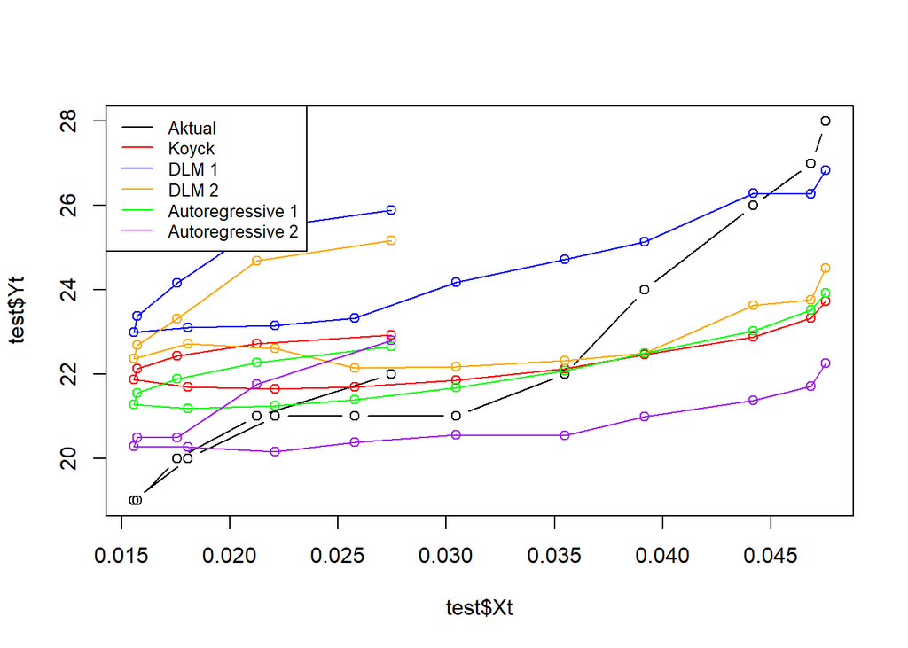

```r
par(mfrow=c(1,1))  # atur layout grafik tunggal

# plot data aktual
plot(test$Xt, test$Yt, type="b", col="black")

# tambahkan garis ramalan dari masing-masing model
points(test$Xt, forec.koyck$forecasts, col="red");   lines(test$Xt, forec.koyck$forecasts, col="red")
points(test$Xt, forec.dlm$forecasts, col="blue");    lines(test$Xt, forec.dlm$forecasts, col="blue")
points(test$Xt, forec.dlm2$forecasts, col="orange"); lines(test$Xt, forec.dlm2$forecasts, col="orange")
points(test$Xt, forec.ardl$forecasts, col="green");  lines(test$Xt, forec.ardl$forecasts, col="green")
points(test$Xt, forec.ardl2$forecasts, col="purple"); lines(test$Xt, forec.ardl2$forecasts, col="purple")
# legenda model
legend("topleft",
       c("Aktual", "Koyck","DLM 1","DLM 2", "Autoregressive 1", "Autoregressive 2"),
       lty=1, col=c("black","red","blue","orange","green","purple"), cex=0.8)
```